# Hypothesis testing

07/20/2020

```r
library(tidyverse)
```

# Hypothesis testing

Similarly to dataset `mtcars`, the dataset `mpg` from `ggplot` package includes data on automobiles. However, `mpg` includes data for newer cars from year 1999 and 2008. The variables measured for each car is slighly different. Here we are interested in the variable, `hwy`, the highway miles per gallon.

```r
# We first format the column trans to contain only info on transmission auto/manual
mpg
```

| manufacturer | model | displ | year | cyl | trans | drv | cty | hwy | fl | class |
| --- | --- | --- | --- | --- | --- | --- | --- | --- | --- | --- |
| audi | a4 | 1.8 | 1999 | 4 | auto(l5) | f | 18 | 29 | p | compact |
| audi | a4 | 1.8 | 1999 | 4 | manual(m5) | f | 21 | 29 | p | compact |
| audi | a4 | 2.0 | 2008 | 4 | manual(m6) | f | 20 | 31 | p | compact |
| audi | a4 | 2.0 | 2008 | 4 | auto(av) | f | 21 | 30 | p | compact |
| audi | a4 | 2.8 | 1999 | 6 | auto(l5) | f | 16 | 26 | p | compact |
| audi | a4 | 2.8 | 1999 | 6 | manual(m5) | f | 18 | 26 | p | compact |
| audi | a4 | 3.1 | 2008 | 6 | auto(av) | f | 18 | 27 | p | compact |
| audi | a4 quattro | 1.8 | 1999 | 4 | manual(m5) | 4 | 18 | 26 | p | compact |
| audi | a4 quattro | 1.8 | 1999 | 4 | auto(l5) | 4 | 16 | 25 | p | compact |
| audi | a4 quattro | 2.0 | 2008 | 4 | manual(m6) | 4 | 20 | 28 | p | compact |

[output cut: 224 more lines]

```r
mpg <- mpg %>%
  mutate(
    transmission = factor(
        gsub("\\((.*)", "", trans), levels = c("auto", "manual"))
  )
mpg
```

| manufacturer | model | displ | year | cyl | trans | drv | cty | hwy | fl | class | transmission |
| --- | --- | --- | --- | --- | --- | --- | --- | --- | --- | --- | --- |
| audi | a4 | 1.8 | 1999 | 4 | auto(l5) | f | 18 | 29 | p | compact | auto |
| audi | a4 | 1.8 | 1999 | 4 | manual(m5) | f | 21 | 29 | p | compact | manual |
| audi | a4 | 2.0 | 2008 | 4 | manual(m6) | f | 20 | 31 | p | compact | manual |
| audi | a4 | 2.0 | 2008 | 4 | auto(av) | f | 21 | 30 | p | compact | auto |
| audi | a4 | 2.8 | 1999 | 6 | auto(l5) | f | 16 | 26 | p | compact | auto |
| audi | a4 | 2.8 | 1999 | 6 | manual(m5) | f | 18 | 26 | p | compact | manual |
| audi | a4 | 3.1 | 2008 | 6 | auto(av) | f | 18 | 27 | p | compact | auto |
| audi | a4 quattro | 1.8 | 1999 | 4 | manual(m5) | 4 | 18 | 26 | p | compact | manual |
| audi | a4 quattro | 1.8 | 1999 | 4 | auto(l5) | 4 | 16 | 25 | p | compact | auto |
| audi | a4 quattro | 2.0 | 2008 | 4 | manual(m6) | 4 | 20 | 28 | p | compact | manual |

[output cut: 224 more lines]

## Part 1: One-sample test

1. Subset the `mpg` dataset to inlude only cars from year 2008.

```r
mpg2008 <- mpg %>%
  filter(year == 2008)
```

```r
t.test(mpg2008$hwy, mu = 30, alternative = "two.sided")
```

```
    One Sample t-test

data:  mpg2008$hwy
t = -12.11, df = 116, p-value < 2.2e-16
alternative hypothesis: true mean is not equal to 30
95 percent confidence interval:
 22.38218 24.52380
sample estimates:
mean of x
 23.45299
```

```r
length(mpg2008$hwy)
```

```
[1] 117
```

3. Test whether cars from 2008 with 4 cylinders have mean `hwy` equal to 30 mpg.

```r
mpg2008_4cyl <- mpg %>%
  filter(year == 2008, cyl == 4)
t.test(mpg2008_4cyl$hwy, mu = 30, alternative = "two.sided")
```

```
    One Sample t-test

data:  mpg2008_4cyl$hwy
t = -1.1492, df = 35, p-value = 0.2582
alternative hypothesis: true mean is not equal to 30
95 percent confidence interval:
 28.15568 30.51098
sample estimates:
mean of x
 29.33333
```

## Part 2: Two-sample test

1. Test if the mean `hwy` for automatic is **less than** that for manual cars **in 2008**. Generate a boxplot with jittered points for `hwy` for each transmission group.

```r
t.test(data = mpg2008, hwy ~ transmission, alternative = "less")
# or
 t.test(x = mpg2008 %>% filter(transmission == "auto") %>% pull(hwy),
        y = mpg2008 %>% filter(transmission == "manual") %>% pull(hwy),
        alternative = "less")
```

[output not shown]

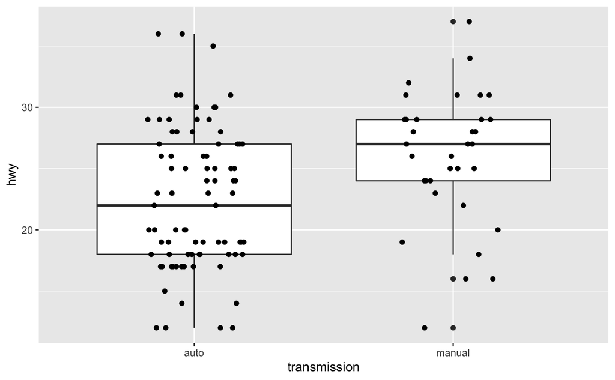

```r
ggplot(mpg2008, aes(x = transmission, y = hwy)) +
  geom_boxplot() + geom_jitter(height = 0, width = 0.2)
```

2. Test if the mean `hwy` for cars from 1999 and is greater than that for cars from 2008. Generate a boxplot with jittered points for `hwy` for each year group.

```r
t.test(data = mpg, hwy ~ year, alternative = "greater")
```

[output not shown]

```r
ggplot(mpg, aes(x = factor(year), y = hwy)) +
  geom_boxplot() + geom_jitter(height = 0, width = 0.2)
```

[output not shown]

## In-class

**Question 1. Diet exercise** Suppose you want to test the efficiency of diet A vs diet B (which will be just a placebo, so no change expected). You have a group of 150 people in each group. You measure their weight on day 1, and then 3 months later.

1. What variable would you use to check the efficiency of the diet? What summary statistic would you use to compare the groups?

*Solution*: we should look at the difference in weights for each individual, that is, define:
$$\Delta_{ig} = X_{ig}^{(1)} - X_{ig}^{(2)}$$
the difference between the weights of individual $i$ in group $g$ between time 1 and 2.

The summary statistic for each group would then be the mean average difference:$\hat{\Delta}_g$. This allows to focus on the efficiency of the treatment (number of pounds lost) while controlling for the patients' different "offsets"/start weights.

2. Write down the null hypothesis.

3. 1. Suppose you want to check if diet A is efficient. What test would you use? This would be simply checking: $\Delta_A = 0$ vs $H_a: \Delta_A \neq 0$. We would thus use a one-sample t-test, with a two-sided alternative.
4. 2. Suppose you want to check if diet A is as efficient as diet B. What test would you use? We would use a two-sample t-test since we're comparing two groups.
5. Run the previous tests on the following (simulated data).

```r
data = data.frame("Control_0"= rnorm(150, 175, 25),
                  "Treatment_0"= rnorm(150, 175, 25))
data$Control_1 = data$Control_0 + rnorm(150, 0, 5)
data$Treatment_1 = data$Treatment_0 + rnorm(150, -7, 5)
print(t.test(data$Treatment_1 - data$Treatment_0,
       mu = 0,
       alternative="two.sided"))
```

```
    One Sample t-test

data:  data$Treatment_1 - data$Treatment_0
t = -18.676, df = 149, p-value < 2.2e-16
alternative hypothesis: true mean is not equal to 0
95 percent confidence interval:
 -8.533592 -6.900562
sample estimates:
mean of x
-7.717077
```

```r
print(t.test(data$Control_1 - data$Control_0,
       data$Treatment_1 - data$Treatment_0,
       alternative="two.sided"))
```

```
    Welch Two Sample t-test

data:  data$Control_1 - data$Control_0 and data$Treatment_1 - data$Treatment_0
t = 14.019, df = 297.11, p-value < 2.2e-16
alternative hypothesis: true difference in means is not equal to 0
95 percent confidence interval:
 7.243271 9.609068
sample estimates:
 mean of x  mean of y
 0.7090933 -7.7170766
```

**Question 2: signed rank test**

1. What does the small sample size entail?

The parametric assumptions around which the test is built are going to fail... We have little data.

2. In this context, it is preferable to use a non-parametric test. For instance, suppose we look at the sign of the difference in weight, and want to devise a test based on the distibution of these signs.

That is, consider $T_g = \sum_{i=1}^{n_g}\frac{1}{2} (\text{sign}(X_{i1} - X_{i0}) + 1)$.

1. Under the null, what is the distribution of this test?

Under the null, there is a fifty-fifty chance of having a negative or positive sign. Thus each $Y_i = \frac{1}{2} (\text{sign}(X_{i1} - X_{i0}) + 1)$ can be considered as a bernouilli variable, taking value 0 with probability 0.5 and 1 with probability 0.5. Thus, the sign distribution $T_g$ follows a binomial distribution with parameter p=0.5.

2. Using the following simulated data, assess whether or not you can reject the null by computing the rejection region and comparing it to your statistic.

```r
data1 = data.frame("Control_0"= rnorm(12, 175, 25),
                  "Treatment_0"= rnorm(12, 175, 25))
data1$Control_1 = data1$Control_0 + rnorm(12, 0, 5)
data1$Treatment_1 = data1$Treatment_0 + rnorm(12, -3, 5)
T_Treat = sum(data1$Treatment_1 - data1$Treatment_0 < 0)
## rejection region under the null
print(paste0("Rejection region: [", qbinom(0.025, 12, 0.5), ", ", qbinom(0.975, 12, 0.5), "]"))
```

```
[1] "Rejection region: [3, 9]"
```

```r
print(paste0("My stat:", T_Treat))
```

```
[1] "My stat:6"
```

Let's compare this to the one-sample t-test,

```r
print(t.test(data1$Treatment_1 - data1$Treatment_0,
       mu = 0,
       alternative="two.sided"))
```

```
    One Sample t-test

data:  data1$Treatment_1 - data1$Treatment_0
t = -1.1372, df = 11, p-value = 0.2796
alternative hypothesis: true mean is not equal to 0
95 percent confidence interval:
 -4.066044  1.295756
sample estimates:
mean of x
-1.385144
```

**Question 3: two-sample test**

Assume $X \sim N(\mu_1, \sigma^2)$ and $Y \sim N(\mu_2, \sigma^2)$. Given $n=6$ observations of $X$

```r
x = c(70, 82, 78, 74, 94, 82)
n = length(x)
```

and 8 of $Y$:

```r
y = c(64, 72, 60, 76, 72, 80, 84, 68)
m = length(y)
```

1. We want to test whether the means are equal vs different. Write down the hypothesis and the alternative. What test would you use? Explain the assumptions you're making.

*Solution*: $H_0: \mu_Y = \mu_X$ vs $H_A: \mu_Y \neq \mu_X$. We could assume that the groups have equal variance. This is an important assumption (results in a difference in how the $s$ (estimated standard deviation) is computed).

```r
t.test(x=x, y=y,alternative="two.sided", var.equal = TRUE)
```

```
    Two Sample t-test

data:  x and y
t = 1.8234, df = 12, p-value = 0.09324
alternative hypothesis: true difference in means is not equal to 0
95 percent confidence interval:
 -1.559502 17.559502
sample estimates:
mean of x mean of y
       80        72
```

```r
t.test(x=x, y=y,alternative="greater", var.equal = TRUE)
```

```
    Two Sample t-test

data:  x and y
t = 1.8234, df = 12, p-value = 0.04662
alternative hypothesis: true difference in means is greater than 0
95 percent confidence interval:
 0.1802451       Inf
sample estimates:
mean of x mean of y
       80        72
```